# Session Eight - Plotting in Base R

### Color adjustment

Composition of colors in a palette can be adjusted (increased or decreased) using function “adjust.color”. This function can be used to adjust opacity and levels of primary colors. Adjustment begins by converting given colors to rgb using “col2rgb()” before making specified changes

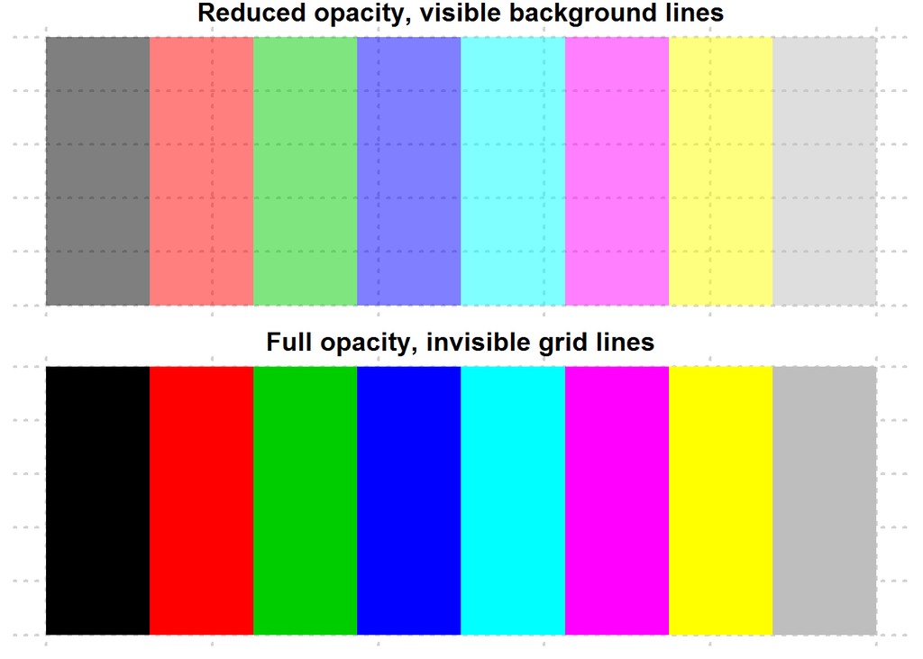

```r
par(mfrow = c(2, 1), mar = c(0.5, 0.5, 1, 0.5))

pal(col = adjustcolor(1:8, 0.5), panel.first = grid(lwd = 2))
title(main = "Reduced opacity, visible background lines", line = 0.2)
pal(col = palette(), panel.first = grid(lwd = 2), )
title(main = "Full opacity, invisible grid lines", line = 0.2)
```

```r
par(mfrow = op$mfrow, mar = op$mar)
```

### Color conversion and Transformation

R provides a number of ways to convert colors from one color space to another. But before making any conversion, it is important to appreciate two things, “color gamut” and “clipping”. A color gamut is a complete range of colors, for example a sRGB color gamut are all the colors available in sRGB color space, this varies from one color space to another, some color spaces have a wider gamut than others, for instance, Adobe RGB has a wider gamut than sRGB. When converting colors from one color space to another, consider differences in gamut particularly if the other color space does not have specified color. Colors not contained in the other color space are said to be out-of-gamut and can either be clipped or returned as NA. Clipping means out-of-gamut colors are converted to another appropriate color which might be slightly different from original color.

Some of the function used for conversion include “convertColor”, “col2rgb”, and “rgb2hsv”

```r
par(mfrow = c(2, 1), mar = c(0.5, 0.5, 1, 0.5))

# Converting palette color names to rgb
rgbColors <- col2rgb(palette())

# A matrix is returned
rgbColors
##       [,1] [,2] [,3] [,4] [,5] [,6] [,7] [,8]
## red      0  255    0    0    0  255  255  190
## green    0    0  205    0  255    0  255  190
## blue     0    0    0  255  255  255    0  190

# Convert rgb to Lab colors
labColors <- convertColor(t(rgbColors), from = "sRGB", to = "Lab", scale.in = 255)
rownames(labColors) <- palette()
labColors
##                L       a.x          b
## black    0.00000   0.00000    0.00000
## red     53.48418  80.01027   67.38407
## green3  71.91841 -73.33548   70.41134
## blue    32.24075  78.82042 -107.93632
## cyan    91.01106 -48.46075  -14.29081
## magenta 60.50231  97.95195  -60.51490
## yellow  97.14950 -21.36677   94.42044
## gray    76.97594   0.00000    0.00000

par(mfrow = op$mfrow, mar = op$mar)
```

- opponent colors, cool/warm colors

#### Interactive plotting on base R

R offers two function for interacting with plots, these are “locator” and “identify”. However, these are platform specific, for locator(), check if your system is supported with function “dev.capabilities()”, for identify() only “X11”, “Windows” and “quartz” support it.

## Other Plotting and Color Palette Packages

A comprehensive list of other packages including those dealing with colors can be sourced from “http://cran.r-project.org/web/view/Graphics.html”

## Graphical Devices

When developing plots in R, outputs are displayed either on screen or externally on what is referred to as graphical devices. All available graphical devices are numbered 1 through 63, with one being default graphing device or “Null device”. Default graphing device is platform specific with windows having “windows”, mac having “quartz” and Linux having “x11”. In addition, RStudio has its own graphing device referred to as “RStudioGD” and usually at the second position and the default piloting device when working on RStudio. External devices include printing and file based devices like “png”, “jpg”, “pdf” and the like.

Generating plots on either base R or RStudio (on screen devices) would result to default graphical device being opened, but for external graphical devices, a call to a device driver function needs to be made before plotting. Calling device drivers before plotting ensure plotting functions can be understood by the other device. Once plotting is finished, device drivers need to be closed. For example, to send a plot to a file such “png”, a call to png’s driver is made before plotting and closed after plotting.

```
png(filename = "plot_one.png")
plot(BOD)
dev.off
```

A list of available device drivers is documented on R’s help page for devices, type help(“device”).

Multiple devices can be open at the same time like RStudioGD, png, and jpeg, however, R can only output to one device at a time. So if all these three devices are opened, the one listed as current or active device will be used. To know which device is current, call “dev.cur()” or “dev.list()” to see all currently available devices.

Active device can be change to another device, which immediately opens the specified device.

```r
# All currently opened devices
dev.list()

# Current device
dev.cur()
## RStudioGD
##         2

# Changing device from RStudio to windows or Null graphical device
dev.set(1)

# Check indeed change was made
dev.cur()
## windows
##       4

# Close of second (png) device
dev.list()
dev.off()
```

Instead of opening an external device before plotting, a plot can be made on screen and sent to an off-screen device by copying the plot. This approach might be good as you get to see the plot being generated and amend as need be before sending to an external device or file.

As an example, we make a plot and copy it to an external file.

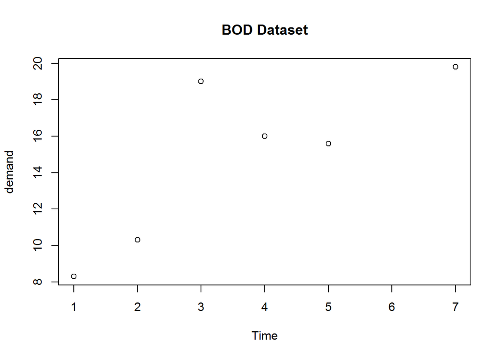

```r
# On screen plotting
plot(BOD, main = "BOD Dataset")
```

```r
# Copy plot to a "png" file (first argument to dev.copy must be a device/function)
dev.copy(png, file = "tmp.png")
## png
##   4

# Establish file is created
file.exists("tmp.png")
## [1] TRUE

# Close device
dev.off()
## pdf
##   2

# Remove file
unlink("tmp.png")

plot(BOD)
```

If there are other open devices and need to shut all of them down, use graphics.off(). This function is automatically called on exit of a session.

```r
dev.list()
## pdf png
##   2   3
graphics.off()
dev.list()
## NULL
```

## References

### Quick reference on functions

1. ?plot
2. ?xy.coords
3. ?axis
4. ?Axis
5. ?box
6. ?plot.window
7. ?device
8. ?par
9. demo(plotmath)
10. ?hist
11. ?n2mfrow

### Packages to read further on

1. Lattice
2. ggplot2
3. Grid
4. MASS(truehist)
5. KernSmooth (dpih)

### R Manuals

#### An Introduction to R sections:

Chapter 12: Graphical procedures

#### R Internals

Chapter 6: Graphics 6.2 Colors

#### Online reference

1. How to solve some plotting problems: https://support.rstudio.com/hc/en-us/articles/200488548-Problem-with-Plots-or-Graphics-Device
2. A good tutorial blog post: http://rpubs.com/SusanEJohnston/7953
3. A comprehensive list of other plotting packages on CRAN https://cran.r-project.org/web/views/Graphics.html
4. Excellent compilation of plot types available in R and graphical devices: http://www.revolutionanalytics.com/r-language-features-graphics-and-visualization
5. Grammar for graphics: http://vita.had.co.nz/papers/layered-grammar.pdf
6. An excellent read on definition of color properties: http://www.workwithcolor.com/color-properties-definitions-0101.htp
7. A good read on colors: color-wheel-artist.com/hue.html
8. An excellent and in depth read on visual perception: vanseodesign.com/web-design/color-luminance/

## Gauge yourself

### Basics of plotting in R

**Exercise**

1. Which are the three basic groups of plotting functions in R
2. If you pass a factor and a numeric vector to plot() what type of graph will be produced?
3. What steps are taken by “plot()” to produce a basic plot?
4. Which base R plotting function is more appropriate for plotting multivariate data involving numeric matrices or data frames. What if they were four variables?

**Solutions**

1. The three groups of plotting functions are high-level plotting functions, low-level functions and interactive functions.
2. A call to plot() will dispatch on class of the first argument. In the case of a factor and numeric, plot will dispatch on factor argument which will be a bar plot.
3. There are roughly eight steps taken by plot() to produce a basic plot, these are: a. Open new plotting window a. Set x and y coordinates a. Evaluate and execute any pre-plot expressions a. Make the actual plot a. Evaluate and execute post-plot and pre-axis expressions a. Add axis if required a. Frame plot if needed a. Annotate, and finally display plot
4. For multivariate plotting, “pairs()” is most suitable for plotting numeric matrices or data frames while “coplot()” is suitable for three or four variables.

### Calling and changing graphical parameters

**Exercises**

1. What do we mean by global and local parameter changes
2. Conceptual exercises a. What is your expectation from this call to par ‘par(mar = rep(2, 2))’

**Solution:**

1. Global changes are changes made to graphical parameters affecting subsequent plotting during an R session. Local changes are temporary changes made to graphical parameters. Global changes are made with call to “par” while local changes are made with call to a plotting function. 1 Expectation a. An error as graphical parameter “mar” requires a vector of length 4 not 2

### Annotating plots

**Exercise**

1. What function is used to add titles and labels?
2. What is the difference between “Axis” and “axis”?
3. How are expressions added to plots

**Solutions** 1. “title()” is used to add titles and labels to plots 1. “Axis” is a generic function used to create user defined labels for numerical axis. “axis” are used to add custom made axes to plots after calling plot().  
1. Expressions are added to plots as either text (using “text” function), marginal text (with function “mtext”), labels (with function “label”) or as axis labels. They however must be “expression” objects

### Producing different base R plots

**Exercise**

1. Reproduce the following plot using BOD data set, one of base R’s data set

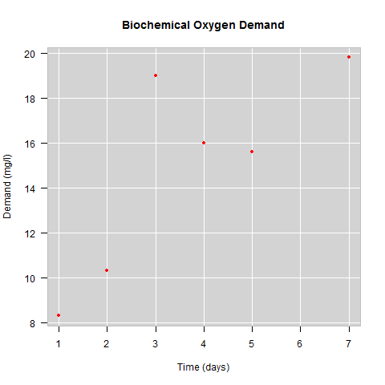

BOD plot

2. Using data set tips from reshape2 package, reproduce the following plot. Colors used are 1, 2, 4, and 5.

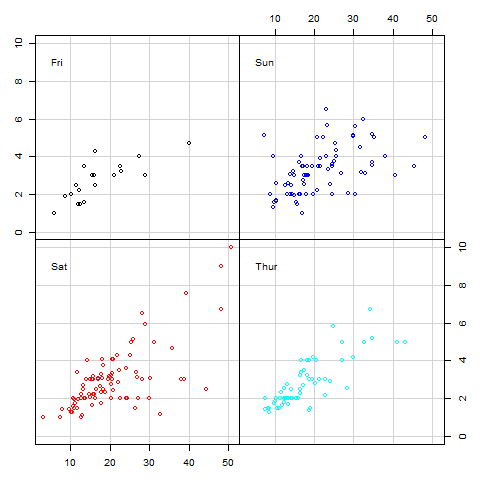

Multipanelling

3. Reproduce figure showing pch characters 1:25

```
##        x  y
##  [1,]  5 25
##  [2,] 10 25
##  [3,] 15 25
##  [4,] 20 25
##  [5,] 25 25
##  [6,]  5 20
##  [7,] 10 20
##  [8,] 15 20
##  [9,] 20 20
## [10,] 25 20
## [11,]  5 15
## [12,] 10 15
## [13,] 15 15
## [14,] 20 15
## [15,] 25 15
## [16,]  5 10
## [17,] 10 10
## [18,] 15 10
## [19,] 20 10
## [20,] 25 10
## [21,]  5  5
## [22,] 10  5
## [23,] 15  5
## [24,] 20  5
## [25,] 25  5
```

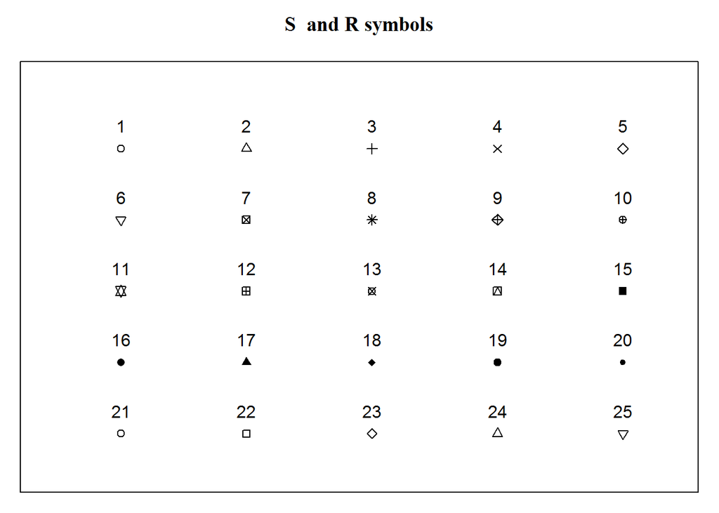

**Solution**

1. Code to reproduce plot

```r
plot(BOD, main = "Biochemical Oxygen Demand", xlab = "Time (days)", ylab = "Demand (mg/l)", pch = 20, col = 4, frame.plot = FALSE, las = 1)
rect(par("usr")[1], par("usr")[3], par("usr")[2], par("usr")[4], col = "lightgrey")
BODcoords <- xy.coords(BOD)
abline(h = seq(8, 20, by = 2), v = 1:7, col = "white")
points(BOD, pch = 20, col = 2)
box(col = "grey")
```

2. Code to reproduce plot

```r
# Setting margins for four plots, one for each day
op <- par(c("mar", "mfcol", "oma"))
par(mar = rep(0, 4), mfcol = c(2, 2), oma = rep(3, 4))

# Subsets
subTips <- lapply(levels(tips$day), function(i) subset(tips, day == i, select = c(total_bill, tip)))
tipsRange <- sapply(subTips, function(x) sapply(x, range))
dimnames(tipsRange)[[1]] <- c("x Minimum", "x Maximum", "y Minimum", "y Maximum")
xlim <- round(c(min(tipsRange["x Minimum",]) - 0.5, max(tipsRange["x Maximum",])))
ylim <- round(c(min(tipsRange["y Minimum",]) - 0.5, max(tipsRange["y Maximum",])))

# Plots showing relationship between "tips" and "total bill" by:
#--------------------------------------------------------------
# First day "Friday"
plot(subTips[[1]]$total_bill, subTips[[1]]$tip, col = 1, xlim = xlim, ylim = ylim, ann = FALSE, axes = FALSE, panel.first = grid(lty = "solid"))
axis(2, cex = 0.6)
box()
text(x = 3.5, y = 9, labels = levels(tips$day)[1], pos = 4, cex = 1)


# Second day "Sat"
plot(subTips[[2]]$total_bill, subTips[[2]]$tip, col = 2, xlim = xlim, ylim = ylim, ann = FALSE, axes = FALSE, panel.first = grid(lty = "solid"))
axis(1)
box()
text(x = 3.5, y = 9, labels = levels(tips$day)[2], pos = 4, cex = 1)

# Third day "Sunday"
plot(subTips[[3]]$total_bill, subTips[[3]]$tip, col = 4, xlim = xlim, ylim = ylim, ann = FALSE, axes = FALSE, panel.first = grid(lty = "solid"))
axis(3)
box()
text(x = 3.5, y = 9, labels = levels(tips$day)[3], pos = 4, cex = 1)

# Fouth day "Thur"
plot(subTips[[4]]$total_bill, subTips[[4]]$tip, col = 5, xlim = xlim, ylim = ylim, ann = FALSE, axes = FALSE, panel.first = grid(lty = "solid"))
axis(4)
box()
text(x = 3.5, y = 9, labels = levels(tips$day)[4], pos = 4, cex = 1)


# Restoring original margins
par(mar = op$mar, mfcol = op$mfcol, oma = op$oma)
```

3. Code to reproduce figure

```r
# Saving a changing layout
op <- par("mar")
par(mar = c(1, 1, 3, 1))

x <- rep.int(seq.int(5, 25, 5), 5)
y <- rep(seq.int(25, 5, -5), each = length(unique(x)))
cbind(x, y)

plot(x, y, ann = FALSE, axes = FALSE, frame.plot = TRUE, xlim = c(2, 27), ylim = c(2, 30), pch = 1:25)
title(main = "S  and R symbols", line = 1.5, font.main = 7)
text(x, y + 1.6, labels = 1:25)

par(mar = op)
```

### Using and creating colors in base R

**Exercise**

1. What type of objects can be passed to color arguments?
2. What is a palette?
3. How many distinct color names does base R have?
4. Distinguish between color models and color spaces
5. What is the difference between “additive” and “subtractive” mixing systems and which system does R use
6. How many possible colors are there in an RGB color space
7. What are the three main color properties?

### R’s graphical devices

**Exercises**

1. What does “Null device” mean?
2. Can you use more than one graphical device?
3. Why would a file containing a plot you have just generated not open?

**Solutions**

1. Null device is the default device which is usually an on screen graphing device like windows (for windows operating system), x11 (for Linux), quartz (for apple) or RStudioGD (when using RStudio)
2. Yes, you just need to tell R which device to use each time you what a different device.
3. One possible reason is that dev.off was not called once plotting was completed and therefore device is still open. Upon completing a plot, it is important to close all open device if they are not being used.